# CA5_Phase2

```python
!cp "/content/drive/MyDrive/xray.zip" .
```

```python
!unzip xray.zip
```

[output not shown]

[output cut: 4946 more lines]

[output not shown]

```python
from tensorflow.keras import *
```

```python
dataGenerator = preprocessing.image.ImageDataGenerator()
```

```python
dataTrain = dataGenerator.flow_from_directory(
    "/content/Data/train",
    target_size = (80, 80),
    color_mode = "grayscale",
    batch_size = 32
)
```

```
Found 5144 images belonging to 3 classes.
```

```python
dataTest = dataGenerator.flow_from_directory(
    "/content/Data/test",
    target_size = (80, 80),
    color_mode = "grayscale",
    batch_size = 32
)
```

```
Found 1288 images belonging to 3 classes.
```

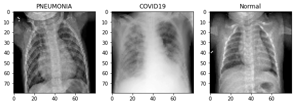

```python
from matplotlib import pyplot as plt
import numpy as np
seen_labels = []
fig, pic = plot_container = plt.subplots(1, 3)
fig.set_size_inches(10, 4)
i = 0
classes_labels = {0: "COVID19", 1: "Normal", 2: "PNEUMONIA"}
batch_img, batch_label = dataTrain.next()
for img, label in zip(batch_img, batch_label):
  class_label = backend.argmax(label).numpy()
  if class_label not in seen_labels:
    pic[i].imshow(img.reshape(80, 80), cmap = 'gray')
    pic[i].set_title(classes_labels[class_label])
    i += 1
    seen_labels.append(class_label)
```

```
<BarContainer object of 3 artists>
```

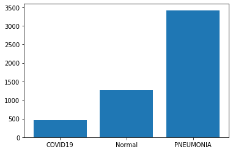

```python
num_classes = dataTrain.num_classes
classes_labels_count = {i:0 for i in range(num_classes)}
for label in dataTrain.classes:
  classes_labels_count[label] += 1
x_labels = [classes_labels[i] for i in range(num_classes)]
y_labels = [classes_labels_count[i] for i in range(num_classes)]
plt.bar(x_labels, y_labels)
```

```python
inp = layers.Input(shape = (80, 80, 1))
out = layers.Flatten()(inp)
out = layers.Dense(2048, activation='relu')(out)
out = layers.Dense(1024, activation='relu')(out)
out = layers.Dense(512, activation='relu')(out)
out = layers.Dense(3, activation='softmax')(out)

model = models.Model(inputs=inp, outputs=out)
model.compile(optimizer=optimizers.SGD(learning_rate=0.01), loss = "categorical_crossentropy", metrics=['accuracy'])
model.summary()
```

```
Model: "model"
_________________________________________________________________
Layer (type)                 Output Shape              Param #
=================================================================
input_1 (InputLayer)         [(None, 80, 80, 1)]       0
_________________________________________________________________
flatten (Flatten)            (None, 6400)              0
_________________________________________________________________
dense (Dense)                (None, 2048)              13109248
_________________________________________________________________
dense_1 (Dense)              (None, 1024)              2098176
_________________________________________________________________
dense_2 (Dense)              (None, 512)               524800
_________________________________________________________________
dense_3 (Dense)              (None, 3)                 1539
=================================================================
Total params: 15,733,763
Trainable params: 15,733,763
Non-trainable params: 0
_________________________________________________________________
```

```python
from sklearn.metrics import classification_report
history = model.fit(dataTrain, validation_data=dataTest, epochs=10, batch_size = 32)
```

```python
pred = model.predict(dataTest)
labels = []
total_batchs = int(np.ceil(len(dataTest.classes) / dataTest.batch_size))
print(total_batchs)
for i in range(total_batchs):
  x,y = dataTest.next()
  for label in y:
    labels.append(backend.argmax(label))
print(classification_report(np.array(labels), backend.argmax(pred).numpy()))
```

```
41
              precision    recall  f1-score   support

           0       0.09      1.00      0.17       116
           1       0.00      0.00      0.00       317
           2       0.00      0.00      0.00       855

    accuracy                           0.09      1288
   macro avg       0.03      0.33      0.06      1288
weighted avg       0.01      0.09      0.01      1288
```

[figure not shown]

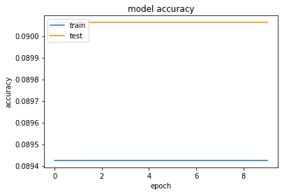

```python
plt.plot(history.history['loss'])
plt.plot(history.history['val_loss'])
plt.title('model loss')
plt.ylabel('loss')
plt.xlabel('epoch')
plt.legend(['train', 'test'], loc='upper left')
plt.show()

plt.plot(history.history['accuracy'])
plt.plot(history.history['val_accuracy'])
plt.title('model accuracy')
plt.ylabel('accuracy')
plt.xlabel('epoch')
plt.legend(['train', 'test'], loc='upper left')
plt.show()
```

```
41
              precision    recall  f1-score   support

           0       0.00      0.00      0.00       116
           1       0.00      0.00      0.00       317
           2       0.66      1.00      0.80       855

    accuracy                           0.66      1288
   macro avg       0.22      0.33      0.27      1288
weighted avg       0.44      0.66      0.53      1288
```

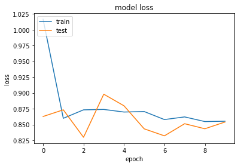

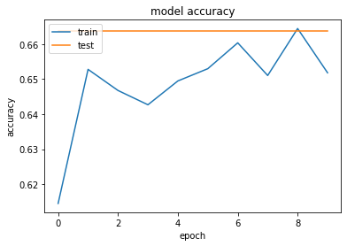

```python
inp = layers.Input(shape = (80, 80, 1))
out = layers.Flatten()(inp)
out = layers.Dense(2048, activation='tanh')(out)
out = layers.Dense(1024, activation='tanh')(out)
out = layers.Dense(512, activation='tanh')(out)
out = layers.Dense(3, activation='softmax')(out)

model = models.Model(inputs=inp, outputs=out)
model.compile(optimizer=optimizers.SGD(learning_rate=0.01), loss = "categorical_crossentropy", metrics=['accuracy'])

history = model.fit(dataTrain, validation_data=dataTest, epochs=10, batch_size = 32)

pred = model.predict(dataTest)
labels = []
total_batchs = int(np.ceil(len(dataTest.classes) / dataTest.batch_size))
print(total_batchs)
for i in range(total_batchs):
  x,y = dataTest.next()
  for label in y:
    labels.append(backend.argmax(label))
print(classification_report(np.array(labels), backend.argmax(pred).numpy()))

plt.plot(history.history['loss'])
plt.plot(history.history['val_loss'])
plt.title('model loss')
plt.ylabel('loss')
plt.xlabel('epoch')
plt.legend(['train', 'test'], loc='upper left')
plt.show()

plt.plot(history.history['accuracy'])
plt.plot(history.history['val_accuracy'])
plt.title('model accuracy')
plt.ylabel('accuracy')
plt.xlabel('epoch')
plt.legend(['train', 'test'], loc='upper left')
plt.show()
```

از آنجایی که داده ها نرمال نشده اند وقتی تابع فعالساز رلو است دچار اورفلو خواهیم شد ولی در حالتی که تابع فعالساز تانژانت هایپربولیک است چون به ازای مقادیر بزرگ به بی نهایت میل نمیکند دچار اورفلو نیستیم ولی باز هم به دقت بالا دست نیافته ایم. برای حل مشکل اورفلو یا میتوان از توابع فعالساز مناسب استفاده کرد یا داده ها را هنگام خواندن نرمالیزه کرد.

```python
dataGenerator = preprocessing.image.ImageDataGenerator(rescale=1/255.0)
dataTrain = dataGenerator.flow_from_directory(
    "/content/Data/train",
    target_size = (80, 80),
    color_mode = "grayscale",
    batch_size = 32
)
dataTest = dataGenerator.flow_from_directory(
    "/content/Data/test",
    target_size = (80, 80),
    color_mode = "grayscale",
    batch_size = 32
)

inp = layers.Input(shape = (80, 80, 1))
out = layers.Flatten()(inp)
out = layers.Dense(2048, activation='relu')(out)
out = layers.Dense(4096, activation='relu')(out)
out = layers.Dense(4096, activation='relu')(out)
out = layers.Dense(1024, activation='relu')(out)
out = layers.Dense(4096, activation='relu')(out)
out = layers.Dense(3, activation='softmax')(out)

model = models.Model(inputs=inp, outputs=out)
```

```
Found 5144 images belonging to 3 classes.
Found 1288 images belonging to 3 classes.
```

Optimizers are algorithms or methods used to change the attributes of the neural network such as weights and learning rate to reduce the losses. Optimizers are used to solve optimization problems by minimizing the function.  
Momentum or SGD with momentum is method which helps accelerate gradients vectors in the right directions, thus leading to faster converging. It is one of the most popular optimization algorithms and many state-of-the-art models are trained using it.

momentum یک پارامتر مانند نرخ یادگیری است. در شرایطی که داده ما دارای نویز است ما همواره در مسیر بهینه پیش نمیرویم و در بروزرسانی وزن ها مشتق ها دارای خطا هستند. در این حالت exponentially weighed averages بهتر عمل میکند و باعث میشود به مقدار واقعی نزدیک تر باشیم.

```
41
              precision    recall  f1-score   support

           0       0.07      0.08      0.08       116
           1       0.20      0.21      0.21       317
           2       0.65      0.64      0.64       855

    accuracy                           0.48      1288
   macro avg       0.31      0.31      0.31      1288
weighted avg       0.49      0.48      0.48      1288
```

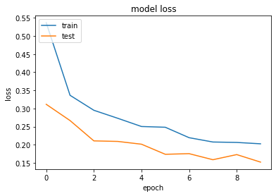

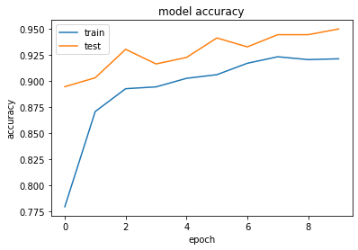

```python
model.compile(optimizer=optimizers.SGD(learning_rate=0.01, momentum=0.5), loss = "categorical_crossentropy", metrics=['accuracy'])
history = model.fit(dataTrain, validation_data=dataTest, epochs=10, batch_size = 32)

pred = model.predict(dataTest)
labels = []
total_batchs = int(np.ceil(len(dataTest.classes) / dataTest.batch_size))
print(total_batchs)
for i in range(total_batchs):
  x,y = dataTest.next()
  for label in y:
    labels.append(backend.argmax(label))
print(classification_report(np.array(labels), backend.argmax(pred).numpy()))

plt.plot(history.history['loss'])
plt.plot(history.history['val_loss'])
plt.title('model loss')
plt.ylabel('loss')
plt.xlabel('epoch')
plt.legend(['train', 'test'], loc='upper left')
plt.show()

plt.plot(history.history['accuracy'])
plt.plot(history.history['val_accuracy'])
plt.title('model accuracy')
plt.ylabel('accuracy')
plt.xlabel('epoch')
plt.legend(['train', 'test'], loc='upper left')
plt.show()
```

```
41
              precision    recall  f1-score   support

           0       0.00      0.00      0.00       116
           1       0.00      0.00      0.00       317
           2       0.66      1.00      0.80       855

    accuracy                           0.66      1288
   macro avg       0.22      0.33      0.27      1288
weighted avg       0.44      0.66      0.53      1288
```

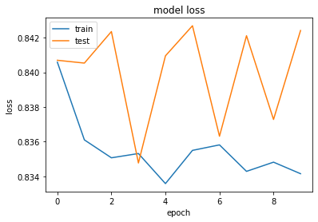

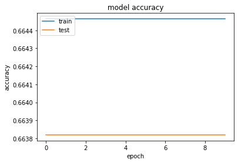

```python
model.compile(optimizer=optimizers.SGD(learning_rate=0.01, momentum=0.9), loss = "categorical_crossentropy", metrics=['accuracy'])
history = model.fit(dataTrain, validation_data=dataTest, epochs=10, batch_size = 32)

pred = model.predict(dataTest)
labels = []
total_batchs = int(np.ceil(len(dataTest.classes) / dataTest.batch_size))
print(total_batchs)
for i in range(total_batchs):
  x,y = dataTest.next()
  for label in y:
    labels.append(backend.argmax(label))
print(classification_report(np.array(labels), backend.argmax(pred).numpy()))

plt.plot(history.history['loss'])
plt.plot(history.history['val_loss'])
plt.title('model loss')
plt.ylabel('loss')
plt.xlabel('epoch')
plt.legend(['train', 'test'], loc='upper left')
plt.show()

plt.plot(history.history['accuracy'])
plt.plot(history.history['val_accuracy'])
plt.title('model accuracy')
plt.ylabel('accuracy')
plt.xlabel('epoch')
plt.legend(['train', 'test'], loc='upper left')
plt.show()
```

```
41
              precision    recall  f1-score   support

           0       0.00      0.00      0.00       116
           1       0.00      0.00      0.00       317
           2       0.66      1.00      0.80       855

    accuracy                           0.66      1288
   macro avg       0.22      0.33      0.27      1288
weighted avg       0.44      0.66      0.53      1288
```

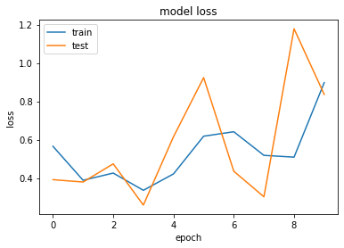

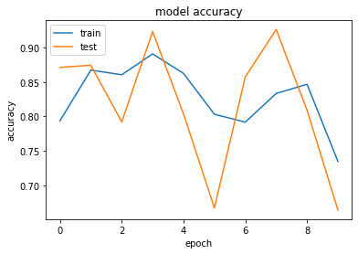

```python
model.compile(optimizer=optimizers.SGD(learning_rate=0.01, momentum=0.99), loss = "categorical_crossentropy", metrics=['accuracy'])
history = model.fit(dataTrain, validation_data=dataTest, epochs=10, batch_size = 32)

pred = model.predict(dataTest)
labels = []
total_batchs = int(np.ceil(len(dataTest.classes) / dataTest.batch_size))
print(total_batchs)
for i in range(total_batchs):
  x,y = dataTest.next()
  for label in y:
    labels.append(backend.argmax(label))
print(classification_report(np.array(labels), backend.argmax(pred).numpy()))

plt.plot(history.history['loss'])
plt.plot(history.history['val_loss'])
plt.title('model loss')
plt.ylabel('loss')
plt.xlabel('epoch')
plt.legend(['train', 'test'], loc='upper left')
plt.show()

plt.plot(history.history['accuracy'])
plt.plot(history.history['val_accuracy'])
plt.title('model accuracy')
plt.ylabel('accuracy')
plt.xlabel('epoch')
plt.legend(['train', 'test'], loc='upper left')
plt.show()
```

همانطور که مشاهده میشود با مقدار ۰.۵ به دقت خوبی میرسیم ولی با دو مقدار دیگر دقت کاهش می یابد و همچنین شاهد این قضیه هستیم که نمودارهای دقت و لاس دچار تغییرات زیادی میشوند. به عبارتی مشتق آنها در تمام نقاط هم علامت نیست. این قضیه به این دلیل است که با زیاد انتخاب کردن این مقدار مقادیر وزن بیش از اندازه تغییر میکنند و باعث میشود که از وزن های بهینه دور شویم. به همین دلیل مقادیر خیلی بزرگ لزوما پاسخ مارا بهتر نمیکنند.

```
41
              precision    recall  f1-score   support

           0       0.00      0.00      0.00       116
           1       0.00      0.00      0.00       317
           2       0.66      1.00      0.80       855

    accuracy                           0.66      1288
   macro avg       0.22      0.33      0.27      1288
weighted avg       0.44      0.66      0.53      1288
```

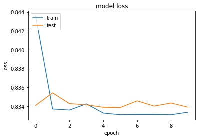

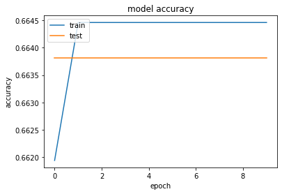

```python
model.compile(optimizer=optimizers.Adam(learning_rate=0.001), loss = "categorical_crossentropy", metrics=['accuracy'])
history = model.fit(dataTrain, validation_data=dataTest, epochs=10, batch_size = 32)

pred = model.predict(dataTest)
labels = []
total_batchs = int(np.ceil(len(dataTest.classes) / dataTest.batch_size))
print(total_batchs)
for i in range(total_batchs):
  x,y = dataTest.next()
  for label in y:
    labels.append(backend.argmax(label))
print(classification_report(np.array(labels), backend.argmax(pred).numpy()))

plt.plot(history.history['loss'])
plt.plot(history.history['val_loss'])
plt.title('model loss')
plt.ylabel('loss')
plt.xlabel('epoch')
plt.legend(['train', 'test'], loc='upper left')
plt.show()

plt.plot(history.history['accuracy'])
plt.plot(history.history['val_accuracy'])
plt.title('model accuracy')
plt.ylabel('accuracy')
plt.xlabel('epoch')
plt.legend(['train', 'test'], loc='upper left')
plt.show()
```

استفاده از آدام مقدار دقت ما را کاهش داد.در صورتی که با momentum برابر ۰.۵ دقت ما را نزدیک به ۹۴ درصد کرده بود. بعضی اوقات آدام همگرایی لازم را ندارد در صورتی که اس جی دی همراه با مامنتوم همگرایی بهتری را برای ما فراهم میکند اما زمان بیشتری میبرد. این اتفاق در بعضی مواقع می افتد. یعضی در بعضی مواقع باید یک جور مصالحه بین زمان و همگرایی داشته باشیم.

```
Found 5144 images belonging to 3 classes.
Found 1288 images belonging to 3 classes.
41
              precision    recall  f1-score   support

           0       0.00      0.00      0.00       116
           1       0.00      0.00      0.00       317
           2       0.66      1.00      0.80       855

    accuracy                           0.66      1288
   macro avg       0.22      0.33      0.27      1288
weighted avg       0.44      0.66      0.53      1288
```

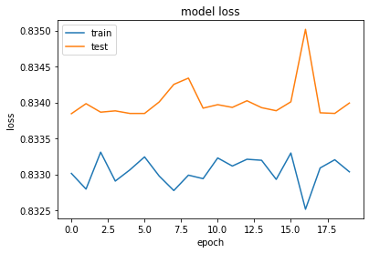

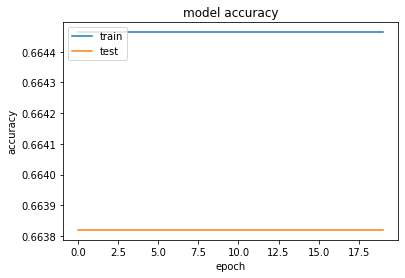

```python
dataTrain = dataGenerator.flow_from_directory(
    "/content/Data/train",
    target_size = (80, 80),
    color_mode = "grayscale",
    batch_size = 32
)
dataTest = dataGenerator.flow_from_directory(
    "/content/Data/test",
    target_size = (80, 80),
    color_mode = "grayscale",
    batch_size = 32
)


model.compile(optimizer=optimizers.Adam(), loss = "categorical_crossentropy", metrics=['accuracy'])
history = model.fit(dataTrain, validation_data=dataTest, epochs=20, batch_size = 32)

pred = model.predict(dataTest)
labels = []
total_batchs = int(np.ceil(len(dataTest.classes) / dataTest.batch_size))
print(total_batchs)
for i in range(total_batchs):
  x,y = dataTest.next()
  for label in y:
    labels.append(backend.argmax(label))
print(classification_report(np.array(labels), backend.argmax(pred).numpy()))

plt.plot(history.history['loss'])
plt.plot(history.history['val_loss'])
plt.title('model loss')
plt.ylabel('loss')
plt.xlabel('epoch')
plt.legend(['train', 'test'], loc='upper left')
plt.show()

plt.plot(history.history['accuracy'])
plt.plot(history.history['val_accuracy'])
plt.title('model accuracy')
plt.ylabel('accuracy')
plt.xlabel('epoch')
plt.legend(['train', 'test'], loc='upper left')
plt.show()
```

اگر فقط یک ایپاک داشته باشیم این بدان معنی است که از هر داده آموزش تنها یک بار استفاده میکنیم. از آنجایی که گرادیانت دیسنت عملی است که با گام های کوچک به حالت بهینه نزدیک میشود بهتر است هر داده را چندین بار ببینیم. به همین دلیل خوب است در همه مسائل از تعداد ایپاک های مناسب استفاده کنیم  
استفاده از ایپاک های خیلی زیاد مناسب نیست. زیرا هم باعث کند شدن فرایند آموزش میشود و هم باعث میشود مدل ما اورفیت کند. یعنی روی داده آموزش به خوبی عمل میکند ولی روی داده تست خوب عمل نمیکند و آن را حفظ میکند. برای جلوگیری از این اتفاق میتوانیم از early stoping استفاده کنیم یعنی هر وقت دیدیم که دقت روی داده تست سقوط کرد فرایند آموزش را متوقف کنیم.

```
Found 5144 images belonging to 3 classes.
Found 1288 images belonging to 3 classes.
41
              precision    recall  f1-score   support

           0       0.00      0.00      0.00       116
           1       0.00      0.00      0.00       317
           2       0.66      1.00      0.80       855

    accuracy                           0.66      1288
   macro avg       0.22      0.33      0.27      1288
weighted avg       0.44      0.66      0.53      1288
```

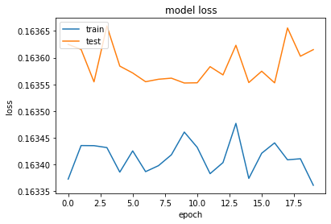

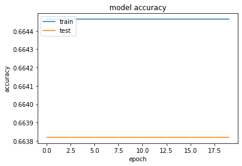

```python
dataTrain = dataGenerator.flow_from_directory(
    "/content/Data/train",
    target_size = (80, 80),
    color_mode = "grayscale",
    batch_size = 32
)
dataTest = dataGenerator.flow_from_directory(
    "/content/Data/test",
    target_size = (80, 80),
    color_mode = "grayscale",
    batch_size = 32
)


model.compile(optimizer=optimizers.Adam(), loss = 'mse' , metrics=['accuracy'])
history = model.fit(dataTrain, validation_data=dataTest, epochs=20, batch_size = 32)

pred = model.predict(dataTest)
labels = []
total_batchs = int(np.ceil(len(dataTest.classes) / dataTest.batch_size))
print(total_batchs)
for i in range(total_batchs):
  x,y = dataTest.next()
  for label in y:
    labels.append(backend.argmax(label))
print(classification_report(np.array(labels), backend.argmax(pred).numpy()))

plt.plot(history.history['loss'])
plt.plot(history.history['val_loss'])
plt.title('model loss')
plt.ylabel('loss')
plt.xlabel('epoch')
plt.legend(['train', 'test'], loc='upper left')
plt.show()

plt.plot(history.history['accuracy'])
plt.plot(history.history['val_accuracy'])
plt.title('model accuracy')
plt.ylabel('accuracy')
plt.xlabel('epoch')
plt.legend(['train', 'test'], loc='upper left')
plt.show()
```

دلیل خوب نبودن mse وجود احتمال است مثلا فرض کنید در یک مسئله احتمالات واقعی [1, 0, 0, 0, 0, 0] است. اگر احتمالات پیش بینی شده [0.2, 0.16, 0.16, 0.16, 0.16, 0.16] باشد در اصل ما درست پیش بینی کرده ایم اما ام اس ای مقداری نزدیک به یک دهم را به عنوان خطا معرفی میکند که ناخوشایند است. البته در این مسئله چندان تفاوتی ایجاد نکرد زیرا داده های آموزش ما غنی هستند. همچنین از دلایل دیگر میتوان به این اشاره کرد که mse فرض میکند دارای توزیع نرمال یا گاوسی هستند.  
در مسائل رگرشن استفاده از آن مطلوب است زیرا به ما میگوید داده های ما چه میزان به خط تصمیم نزدیک هستند.

```
Found 5144 images belonging to 3 classes.
Found 1288 images belonging to 3 classes.
41
              precision    recall  f1-score   support

           0       0.06      0.05      0.06       116
           1       0.27      0.11      0.16       317
           2       0.67      0.83      0.74       855

    accuracy                           0.58      1288
   macro avg       0.33      0.33      0.32      1288
weighted avg       0.52      0.58      0.53      1288
```

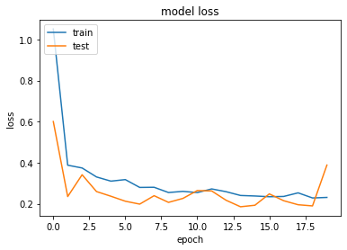

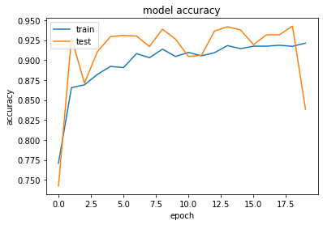

```python
dataTrain = dataGenerator.flow_from_directory(
    "/content/Data/train",
    target_size = (80, 80),
    color_mode = "grayscale",
    batch_size = 32
)
dataTest = dataGenerator.flow_from_directory(
    "/content/Data/test",
    target_size = (80, 80),
    color_mode = "grayscale",
    batch_size = 32
)
inp = layers.Input(shape = (80, 80, 1))
out = layers.Flatten()(inp)
out = layers.Dense(2048, activation='relu', activity_regularizer=regularizers.l2(1e-4))(out)
out = layers.Dense(4096, activation='relu', activity_regularizer=regularizers.l2(1e-4))(out)
out = layers.Dense(4096, activation='relu', activity_regularizer=regularizers.l2(1e-4))(out)
out = layers.Dense(1024, activation='relu', activity_regularizer=regularizers.l2(1e-4))(out)
out = layers.Dense(4096, activation='relu', activity_regularizer=regularizers.l2(1e-4))(out)
out = layers.Dense(3, activation='softmax')(out)

model = models.Model(inputs=inp, outputs=out)

model.compile(optimizer=optimizers.Adam(), loss = "categorical_crossentropy", metrics=['accuracy'])
history = model.fit(dataTrain, validation_data=dataTest, epochs=20, batch_size = 32)

pred = model.predict(dataTest)
labels = []
total_batchs = int(np.ceil(len(dataTest.classes) / dataTest.batch_size))
print(total_batchs)
for i in range(total_batchs):
  x,y = dataTest.next()
  for label in y:
    labels.append(backend.argmax(label))
print(classification_report(np.array(labels), backend.argmax(pred).numpy()))

plt.plot(history.history['loss'])
plt.plot(history.history['val_loss'])
plt.title('model loss')
plt.ylabel('loss')
plt.xlabel('epoch')
plt.legend(['train', 'test'], loc='upper left')
plt.show()

plt.plot(history.history['accuracy'])
plt.plot(history.history['val_accuracy'])
plt.title('model accuracy')
plt.ylabel('accuracy')
plt.xlabel('epoch')
plt.legend(['train', 'test'], loc='upper left')
plt.show()
```

مشاهده میشود دقت به شدت بالا رفته و به ۹۳ درصد نزدیک شده است. همچنین در بعضی ایپاک ها مشاهده میشود دقت داده تست از داده آموزش بیشتر است. این به دلیل وجود همین l2 است که با کم نگه داشتن مقادیر وزن از اورفیت کردن آن جلوگیری میکند. این کار را با اضافه کردن یک تابع خطا برای وزن های بزرگ انجام میدهد در نتیجه وزن ها تمایل دارند کوچک بمانند.

```python
import numpy as np

dataTrain = dataGenerator.flow_from_directory(
    "/content/Data/train",
    target_size = (80, 80),
    color_mode = "grayscale",
    batch_size = 32
)
dataTest = dataGenerator.flow_from_directory(
    "/content/Data/test",
    target_size = (80, 80),
    color_mode = "grayscale",
    batch_size = 32
)
inp = layers.Input(shape = (80, 80, 1))
out = layers.Flatten()(inp)
out = layers.Dense(2048, activation='relu', activity_regularizer=regularizers.l2(1e-4))(out)
out = layers.Dropout(0.1)(out)
out = layers.Dense(4096, activation='relu', activity_regularizer=regularizers.l2(1e-4))(out)
out = layers.Dropout(0.1)(out)
out = layers.Dense(4096, activation='relu', activity_regularizer=regularizers.l2(1e-4))(out)
out = layers.Dropout(0.1)(out)
out = layers.Dense(1024, activation='relu', activity_regularizer=regularizers.l2(1e-4))(out)
out = layers.Dropout(0.1)(out)
out = layers.Dense(4096, activation='relu', activity_regularizer=regularizers.l2(1e-4))(out)
out = layers.Dropout(0.1)(out)
out = layers.Dense(3, activation='softmax')(out)

model = models.Model(inputs=inp, outputs=out)

model.compile(optimizer=optimizers.Adam(), loss = "categorical_crossentropy", metrics=['accuracy'])
history = model.fit(dataTrain, validation_data=dataTest, epochs=20, batch_size = 32)
```

```
Found 5144 images belonging to 3 classes.
Found 1288 images belonging to 3 classes.
```

```
41
              precision    recall  f1-score   support

           0       0.00      0.00      0.00       116
           1       0.00      0.00      0.00       317
           2       0.66      1.00      0.80       855

    accuracy                           0.66      1288
   macro avg       0.22      0.33      0.27      1288
weighted avg       0.44      0.66      0.53      1288
```

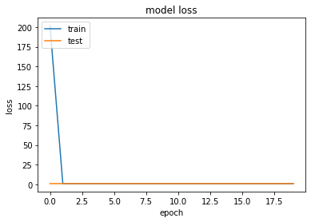

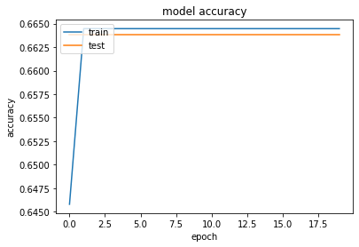

```python
from matplotlib import pyplot as plt
from sklearn.metrics import classification_report
pred = model.predict(dataTest)
labels = []
total_batchs = int(np.ceil(len(dataTest.classes) / dataTest.batch_size))
print(total_batchs)
for i in range(total_batchs):
  x,y = dataTest.next()
  for label in y:
    labels.append(backend.argmax(label))
print(classification_report(np.array(labels), backend.argmax(pred).numpy()))

plt.plot(history.history['loss'])
plt.plot(history.history['val_loss'])
plt.title('model loss')
plt.ylabel('loss')
plt.xlabel('epoch')
plt.legend(['train', 'test'], loc='upper left')
plt.show()

plt.plot(history.history['accuracy'])
plt.plot(history.history['val_accuracy'])
plt.title('model accuracy')
plt.ylabel('accuracy')
plt.xlabel('epoch')
plt.legend(['train', 'test'], loc='upper left')
plt.show()
```